# ActivityTrack

This assignment will be described in multiple parts. You will need to write a report that answers the questions detailed below.

1. Loading and preprocessing the data
2. What is mean total number of steps taken per day?
3. What is the average daily activity pattern?
4. Imputing missing values

## Loading and preprocessing the data

1.1 Using readCSV() load the data.

```r
  if (!require("knitr")) {
   install.packages("knitr")
  }

  if (!require("utils")) {
   install.packages("utils")
  }
  require("knitr")
  require("utils")

  df = read.csv(file="C:/Git/Mod_5_Ass_1/activity.csv", header=TRUE, sep=",")
```

1.2 Before we process the data, let us examine the data. Get a data summary

```r
  summary(df)
```

```
##      steps                date          interval
##  Min.   :  0.00   2012-10-01:  288   Min.   :   0.0
##  1st Qu.:  0.00   2012-10-02:  288   1st Qu.: 588.8
##  Median :  0.00   2012-10-03:  288   Median :1177.5
##  Mean   : 37.38   2012-10-04:  288   Mean   :1177.5
##  3rd Qu.: 12.00   2012-10-05:  288   3rd Qu.:1766.2
##  Max.   :806.00   2012-10-06:  288   Max.   :2355.0
##  NA's   :2304     (Other)   :15840
```

1.3 Display the internal structure of df

```r
  str(df)
```

```
## 'data.frame':    17568 obs. of  3 variables:
##  $ steps   : int  NA NA NA NA NA NA NA NA NA NA ...
##  $ date    : Factor w/ 61 levels "2012-10-01","2012-10-02",..: 1 1 1 1 1 1 1 1 1 1 ...
##  $ interval: int  0 5 10 15 20 25 30 35 40 45 ...
```

## What is mean total number of steps taken per day?

2.1 Using aggregate, get the sum of steps in a given day

```r
 if (!require("stats")) {
   install.packages("stats")
  }
  require("stats")
 #total number of steps per date
 mdata <- aggregate(steps ~ date, data = df, sum)

 head(mdata)
```

```
##         date steps
## 1 2012-10-02   126
## 2 2012-10-03 11352
## 3 2012-10-04 12116
## 4 2012-10-05 13294
## 5 2012-10-06 15420
## 6 2012-10-07 11015
```

```r
#summary(mdata)
```

2.2 Make a histogram of the total number of steps taken each day

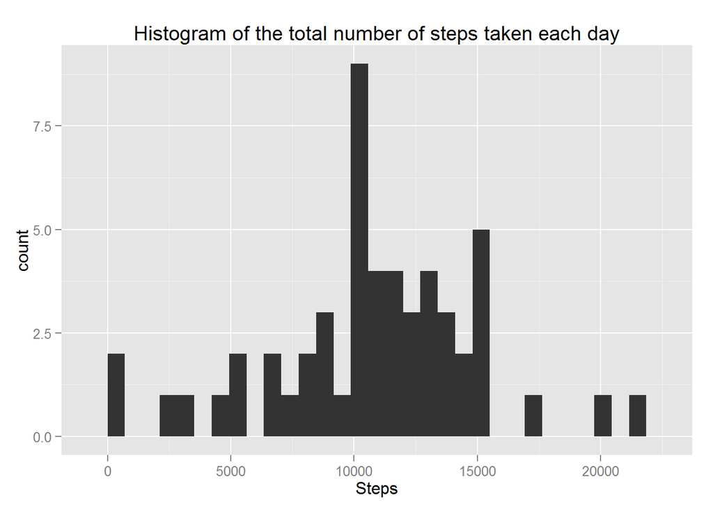

```r
  if (!require("ggplot2")) {
    install.packages("ggplot2")
  }

  require("ggplot2")
  #plot data
  a <- ggplot(data = mdata, aes(steps))
  a <- a + xlab("Steps") + ggtitle("Histogram of the total number of steps taken each day") + geom_histogram()

  print(a)
```

###Calculate and report the mean and median of the total number of steps taken per day 3.1 Calculate the Mean of the total number of Steps Per day

```r
  mean(mdata$steps)
```

```
## [1] 10766.19
```

3.2 Calculate the Median of the total number of Steps Per day

```r
  median(mdata$steps)
```

```
## [1] 10765
```

## What is the average daily activity pattern?

4.1 Calculate the average number of steps for each interval.

```r
  #calculate average number of steps per interval
  avstepsperinterval <- aggregate(steps ~ interval, data = df, mean)
```

4.2 Plot the time series graph.

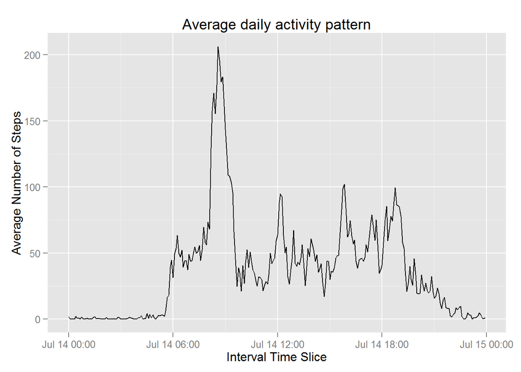

```r
 if (!require("ggplot2")) {
    install.packages("ggplot2")
  }
  #plot data
  require("ggplot2")
  a <- ggplot(data=avstepsperinterval, aes(x = strptime(sprintf("%04d", interval), format="%H%M"),steps))
  a <- a + geom_line() +  scale_color_manual(values=c("#CC6666", "#9999CC"))
  a <- a + xlab("Interval Time Slice") + ylab("Average Number of Steps") + ggtitle("Average daily activity pattern")
  print(a)
```

4.3.1 Add the timesliced to it’s own vector.

```r
  #create the timeline interval
  timeslicedInterval<-strptime(sprintf("%04d", avstepsperinterval$interval), format="%H%M")
  head(timeslicedInterval)
```

```
## [1] "2015-07-14 00:00:00 BST" "2015-07-14 00:05:00 BST"
## [3] "2015-07-14 00:10:00 BST" "2015-07-14 00:15:00 BST"
## [5] "2015-07-14 00:20:00 BST" "2015-07-14 00:25:00 BST"
```

4.3.2 Add the vector to the **avstepsperinterval** variable.

```r
   #add the time sliced data to the avstepsperinterval variable
   avstepsperinterval<-cbind(avstepsperinterval,timeslicedInterval)
```

4.3.3 Using Summary get the Max number of steps.

```r
  summary(avstepsperinterval)
```

```
##     interval          steps         timeslicedInterval
##  Min.   :   0.0   Min.   :  0.000   Min.   :2015-07-14 00:00:00
##  1st Qu.: 588.8   1st Qu.:  2.486   1st Qu.:2015-07-14 05:58:45
##  Median :1177.5   Median : 34.113   Median :2015-07-14 11:57:30
##  Mean   :1177.5   Mean   : 37.383   Mean   :2015-07-14 11:57:30
##  3rd Qu.:1766.2   3rd Qu.: 52.835   3rd Qu.:2015-07-14 17:56:15
##  Max.   :2355.0   Max.   :206.170   Max.   :2015-07-14 23:55:00
```

## Imputing missing values

5.1 Calculate and report the total number of missing values in the dataset?

```r
  #count the number of NA's
  sum(is.na(df$steps))
```

```
## [1] 2304
```

5.2 Devise a strategy for filling in all of the missing values in the dataset. The strategy does not need to be sophisticated.

```r
  imputedmean<-df
  #replace NA's with 0
  imputedmean[is.na(imputedmean)] <- 0
```

5.2.1 Inspect the new dataset **imputedmean**.

```r
  #inspect the data
  head(imputedmean)
```

```
##   steps       date interval
## 1     0 2012-10-01        0
## 2     0 2012-10-01        5
## 3     0 2012-10-01       10
## 4     0 2012-10-01       15
## 5     0 2012-10-01       20
## 6     0 2012-10-01       25
```

```r
  summary(imputedmean)
```

```
##      steps                date          interval
##  Min.   :  0.00   2012-10-01:  288   Min.   :   0.0
##  1st Qu.:  0.00   2012-10-02:  288   1st Qu.: 588.8
##  Median :  0.00   2012-10-03:  288   Median :1177.5
##  Mean   : 32.48   2012-10-04:  288   Mean   :1177.5
##  3rd Qu.:  0.00   2012-10-05:  288   3rd Qu.:1766.2
##  Max.   :806.00   2012-10-06:  288   Max.   :2355.0
##                   (Other)   :15840
```

5.3 Make a histogram of the total number of steps taken each day and Calculate and report the mean and median total number of steps taken per day.

5.3.1 Using aggregate calculate the total number of steps each day

```r
  #Get the total number of steps
  totalstepsperdays <- aggregate(steps ~ date, data = imputedmean, sum)
```

5.3.2 Inspect the data

```r
  head(totalstepsperdays)
```

```
##         date steps
## 1 2012-10-01     0
## 2 2012-10-02   126
## 3 2012-10-03 11352
## 4 2012-10-04 12116
## 5 2012-10-05 13294
## 6 2012-10-06 15420
```

```r
  summary(totalstepsperdays)
```

```
##          date        steps
##  2012-10-01: 1   Min.   :    0
##  2012-10-02: 1   1st Qu.: 6778
##  2012-10-03: 1   Median :10395
##  2012-10-04: 1   Mean   : 9354
##  2012-10-05: 1   3rd Qu.:12811
##  2012-10-06: 1   Max.   :21194
##  (Other)   :55
```

5.3.2 Make a histogram of the total number of steps taken each day.

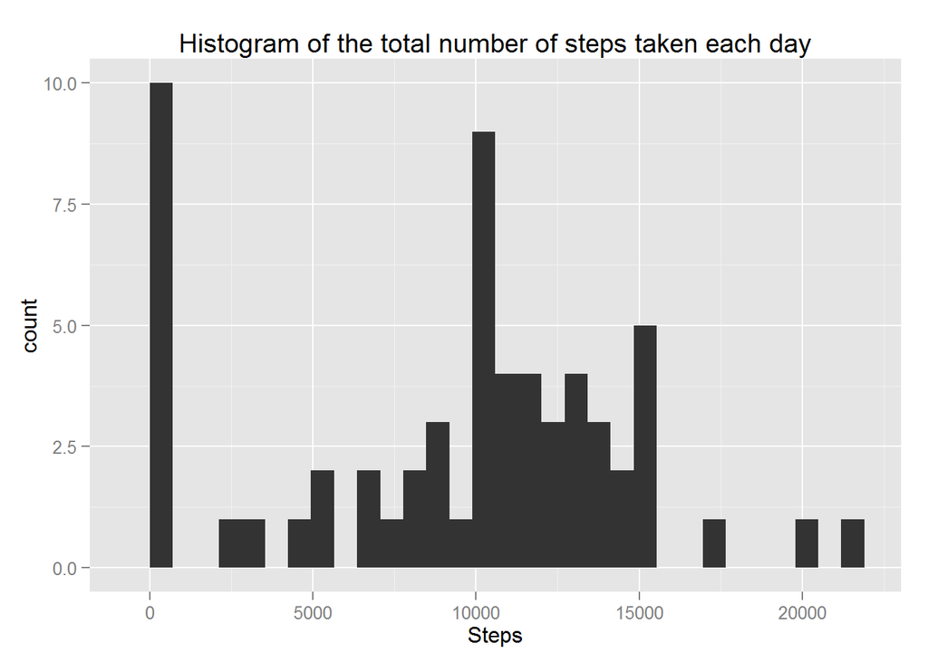

```r
 if (!require("ggplot2")) {
    install.packages("ggplot2")
  }

  require("ggplot2")
  #plot the histogram
  a <- ggplot(data = totalstepsperdays, aes(steps))
  a <- a + xlab("Steps") + ggtitle("Histogram of the total number of steps taken each day") + geom_histogram()

  print(a)
```

5.4.1 Replace NA’s with the Mean.

```r
  #replace NA's with mean
  imputedmean2<-df
  for(i in 1:nrow(imputedmean2)) {

    if(is.na(imputedmean2$steps[i]))
      #replace NA's with mean in avstepsperinterval$steps
      imputedmean2$steps[i] <- avstepsperinterval$steps[i]
  }

  head(imputedmean2)
```

```
##       steps       date interval
## 1 1.7169811 2012-10-01        0
## 2 0.3396226 2012-10-01        5
## 3 0.1320755 2012-10-01       10
## 4 0.1509434 2012-10-01       15
## 5 0.0754717 2012-10-01       20
## 6 2.0943396 2012-10-01       25
```

5.4.2 Get a new total using imputed data frame with mean.

```r
  #Get a new total using imputed data frame with mean
  totalstepsperdays_with_mean_data <- aggregate(steps ~ date, data = imputedmean2, sum)
  head(totalstepsperdays_with_mean_data)
```

```
##         date    steps
## 1 2012-10-01 10766.19
## 2 2012-10-02   126.00
## 3 2012-10-03 11352.00
## 4 2012-10-04 12116.00
## 5 2012-10-05 13294.00
## 6 2012-10-06 15420.00
```

5.4.3 Graph the imputed data with the mean.

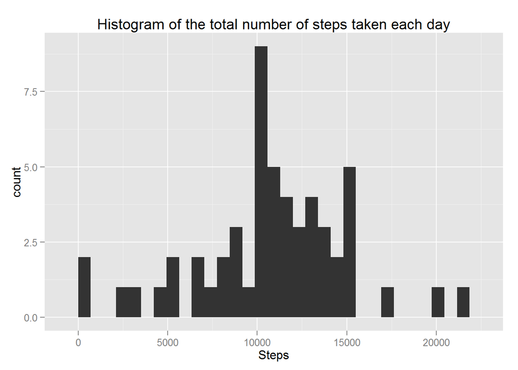

```r
 if (!require("ggplot2")) {
    install.packages("ggplot2")
  }

  require("ggplot2")

  #plot the histogram
  a <- ggplot(data = totalstepsperdays_with_mean_data, aes(steps))
  a <- a + xlab("Steps") + ggtitle("Histogram of the total number of steps taken each day") + geom_histogram()

  print(a)
```

5.3.3 Do these values differ from the estimates from the first part of the assignment?

This was interesting, because this depends on what strategy you use. Orinaly I used the strategy where all NA’s were replaced by 0. I did this, thinking it would have no affect on calculations. However, there was a change in the histogram, because now we have an increase in 0’s.

## Are there differences in activity patterns between weekdays and weekends?

6.1 Create a new factor variable in the dataset with two levels - “weekday” and “weekend” indicating whether a given date is a weekday or weekend day?

6.1.1 Identify weekends.

```r
  if (!require("timeDate")) {
    install.packages("timeDate")
  }

  require("timeDate")

  #replace NA's with mean
  fulldata<-df
  for(i in 1:nrow(fulldata)) {

    if(is.na(fulldata$steps[i])){
      #replace NA's with mean in avstepsperinterval$steps
      fulldata$steps[i]<- avstepsperinterval$steps[i]
    }
  }
  head(fulldata)
```

```
##       steps       date interval
## 1 1.7169811 2012-10-01        0
## 2 0.3396226 2012-10-01        5
## 3 0.1320755 2012-10-01       10
## 4 0.1509434 2012-10-01       15
## 5 0.0754717 2012-10-01       20
## 6 2.0943396 2012-10-01       25
```

```r
  fulldata$isaweekend <-isWeekday(as.POSIXct(fulldata$date))

 #replace true and false with weekend or weekday
 for(i in 1:nrow( fulldata)) {

    if(fulldata$isaweekend[i] ==FALSE){
        #replace FALSE with weekday
        fulldata$isaweekend[i] <- "weekday"
      }else{
         #replace TRUE with weekend
        fulldata$isaweekend[i] <- "weekend"
      }
  }
```

6.1.2 Find the mean steps per interval and weekday/weekend.

```r
  weekday_and_weekend_ave <-
    aggregate(steps~ interval+ isaweekend, data=fulldata,FUN=mean)

  weekday_and_weekend_ave$isaweekend <- as.factor(weekday_and_weekend_ave$isaweekend)
  head(weekday_and_weekend_ave)
```

```
##   interval isaweekend       steps
## 1        0    weekday 0.901306241
## 2        5    weekday 0.026124819
## 3       10    weekday 0.010159652
## 4       15    weekday 0.011611030
## 5       20    weekday 0.005805515
## 6       25    weekday 6.853410740
```

6.1.3 Plot Graph.

```r
  if (!require("ggplot2")) {
   install.packages("ggplot2")
  }
  head(weekday_and_weekend_ave)
```

```
##   interval isaweekend       steps
## 1        0    weekday 0.901306241
## 2        5    weekday 0.026124819
## 3       10    weekday 0.010159652
## 4       15    weekday 0.011611030
## 5       20    weekday 0.005805515
## 6       25    weekday 6.853410740
```

[figure not shown]

```r
  require("ggplot2")
  a <- ggplot(data=weekday_and_weekend_ave, aes(x = interval,
                                                y = steps,
                                                colour=isaweekend,
                                                group=isaweekend))
  a <- a + geom_line()
  a <- a +facet_grid(.~isaweekend)
  a <- a + xlab("Interval") + ylab("Steps") + ggtitle("Weekend Versus Weekday Activity")
  print(a)
```